QA Summary  
MLRA 26 - Jubilee loam, 0 to 2 percent slopes  
report version 0.3  
2018-08-13 13:22

This report requires setting up a selected set in your local NASIS database:

- load project by name
- add data associated with MLRA map units into *mapunit table*
- add data associated with old and new DMU into *data mapunit table*

## Project Description

"Jubilee loam, 0 to 2 percent slopes" units are in MLRA 26, Carson Basin and Mountains, and are part of the MLRA map unit consolidation (SDJR) project. This mapunit '2w371' , was created for the "SDJR - MLRA 26 - MPC - Jub ilee loam, 0 to 2 percent slopes". It replaced the following mapunits in the following Soil Survey legends:

pmnd 1r0vx 1v6fd

The map unit concepts will be determined from information found in the original manuscripts and from tacit knowledge of soil scientists familiar with the mapping and area. The new DMU(s) will be populated to current standards using existing data, KSSL data, and field notes. These data map units will be reviewed and combined into 1 new MLRA DMU if appropriate. Any map units that cannot be combined during this SDJR project or require further investigation like substatial field or spatial work will be documented and flagged as potential MLRA update projects.

## Affected Map Units

```
##   areasymbol musym nationalmusym mutype
## 2      26686   500         1v6fd   <NA>
## 3      CA686   500         1r0vx   <NA>
## 4      NV773  6369          pmnd   <NA>
## 1       <NA>    NA         2w371   <NA>
```

## Component Breakdown

```
##    vintage    compname comppct_r
## 1      old     Jubilee         5
## 2      old     Jubilee        85
## 3      old     Jubilee        95
## 4      old  Kimmerling         5
## 5      old Mindlebaugh         5
## 6      old    Heidtman         5
## 7      new     Jubilee        85
## 8      new Mindlebaugh         5
## 9      new    Heidtman         5
## 10     new  Kimmerling         5
```

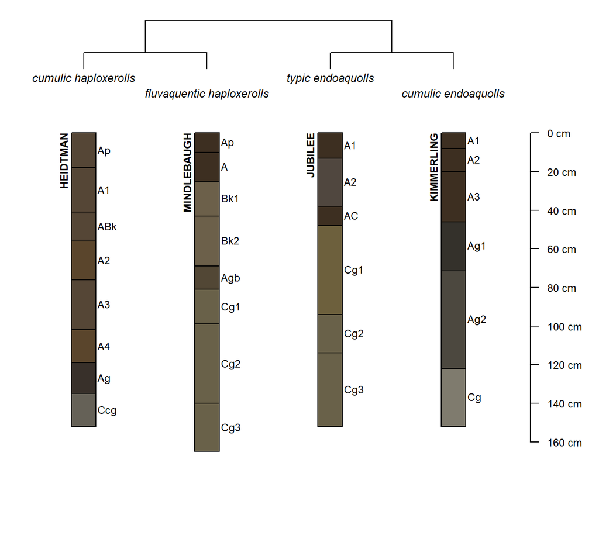

## Profile Sketches

Groups are formed by the new national map unit symbol / component name. Profiles associated with the "old" DMU are labeled with the parent `dmudesc`. Profiles associated with the "new" MLRA DMU are labeled as `*NEW*`.

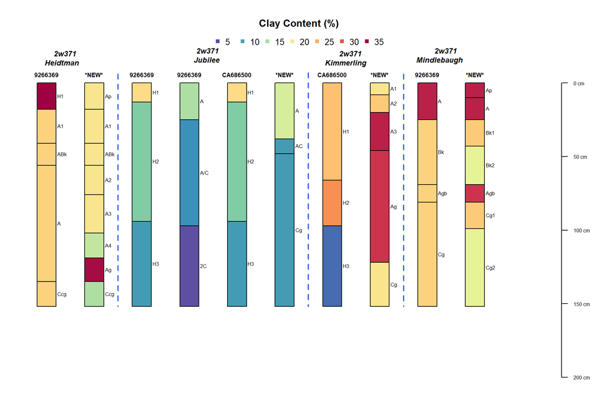

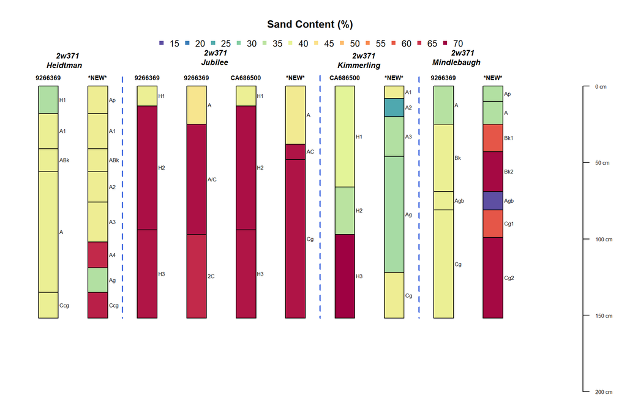

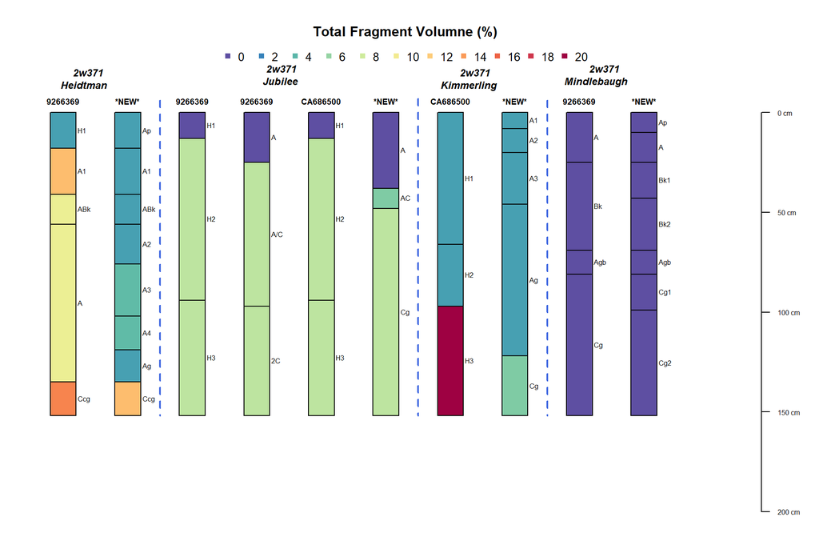

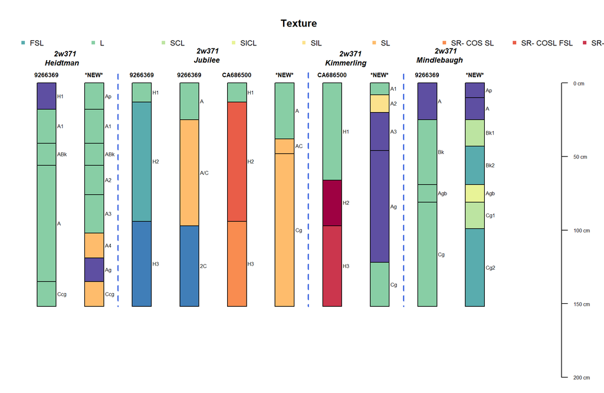

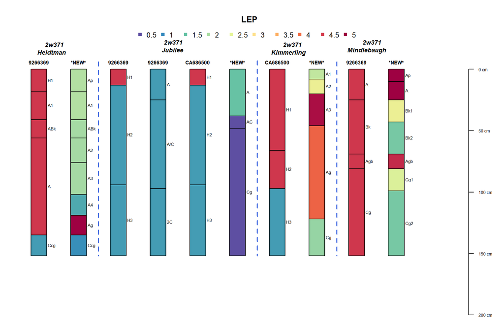

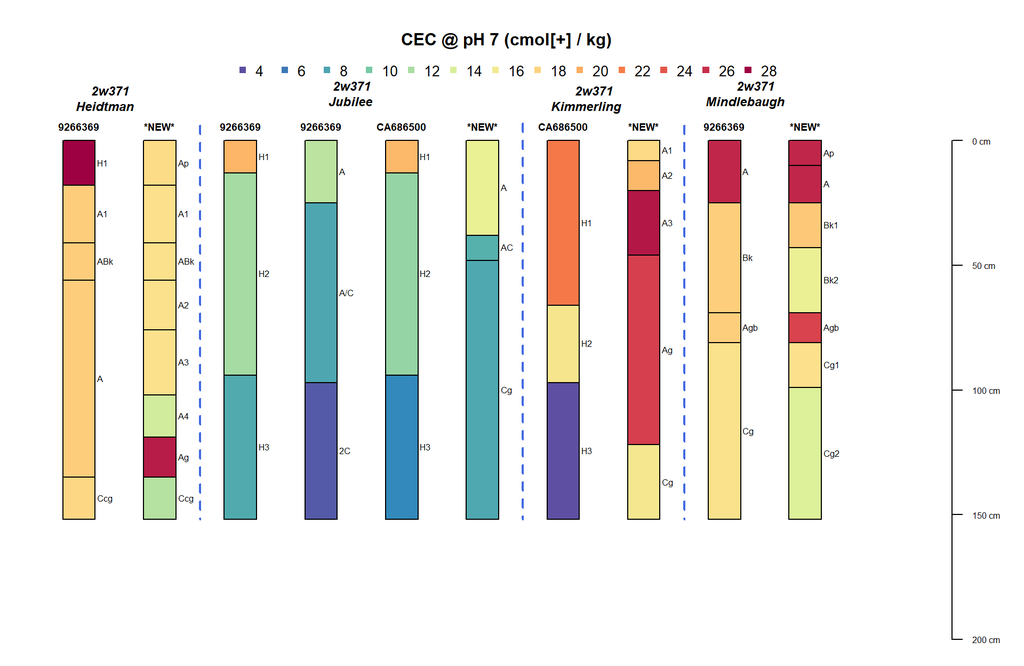

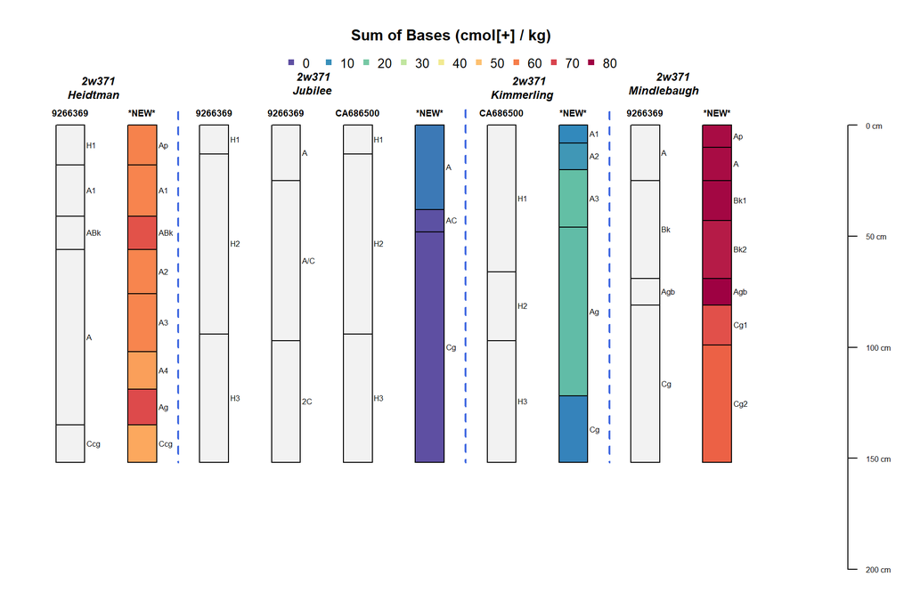

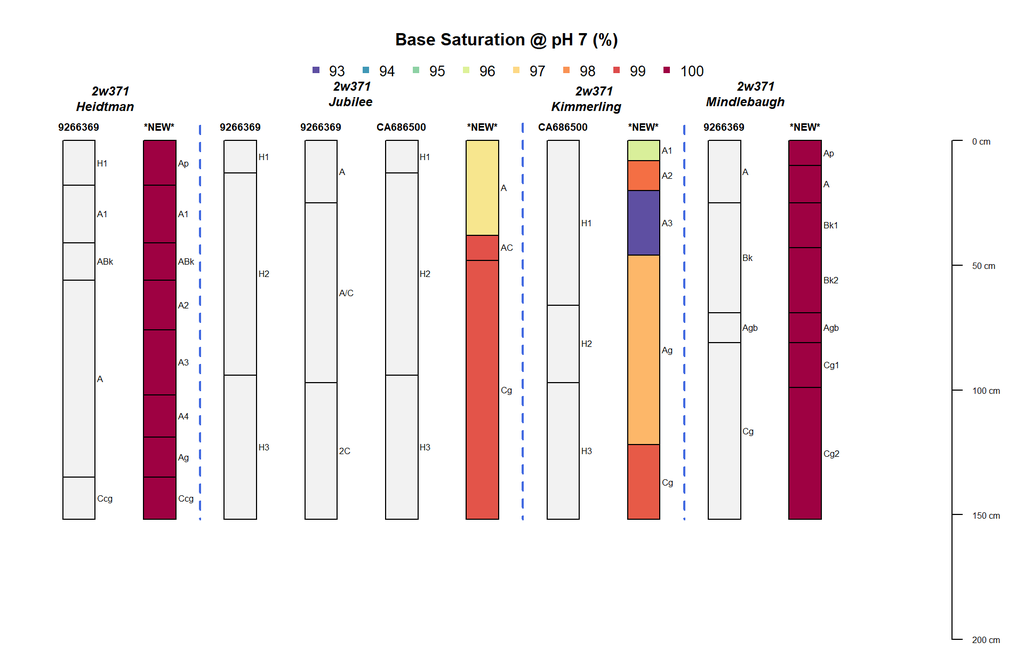

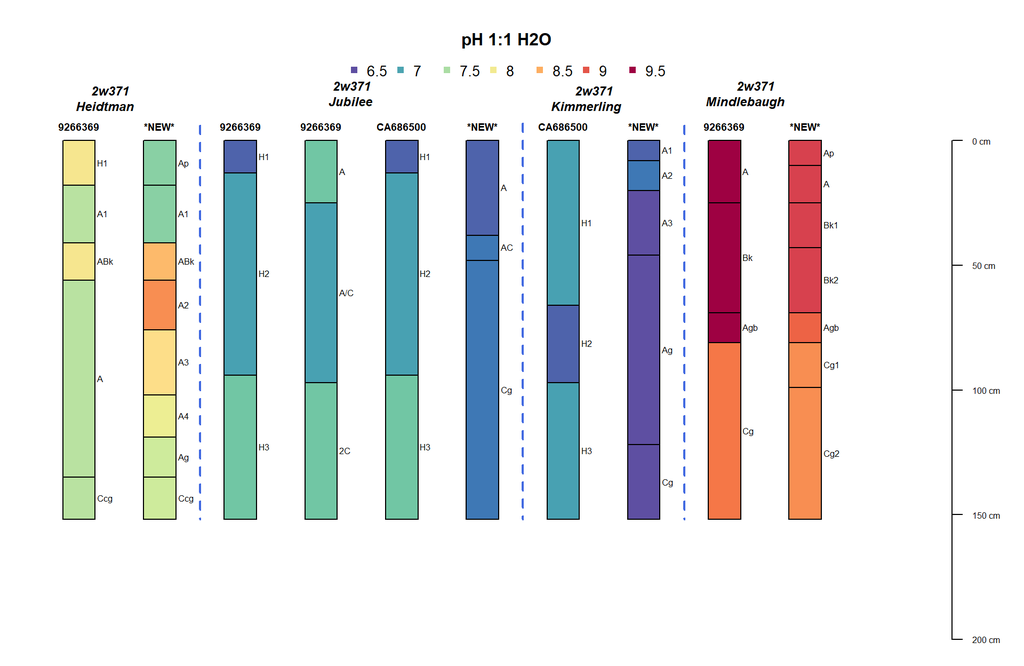

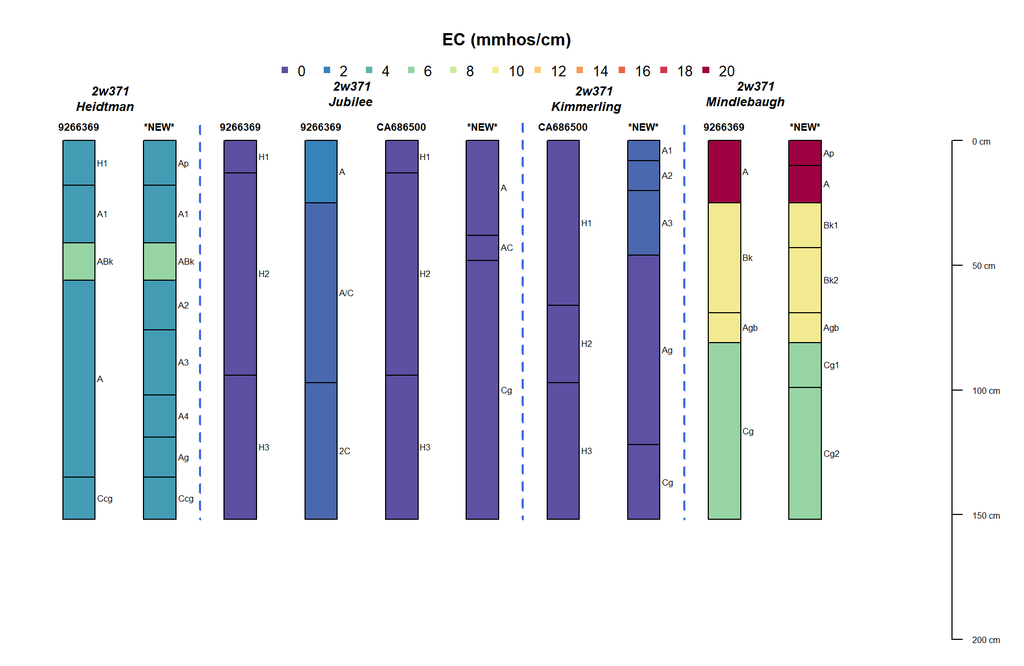

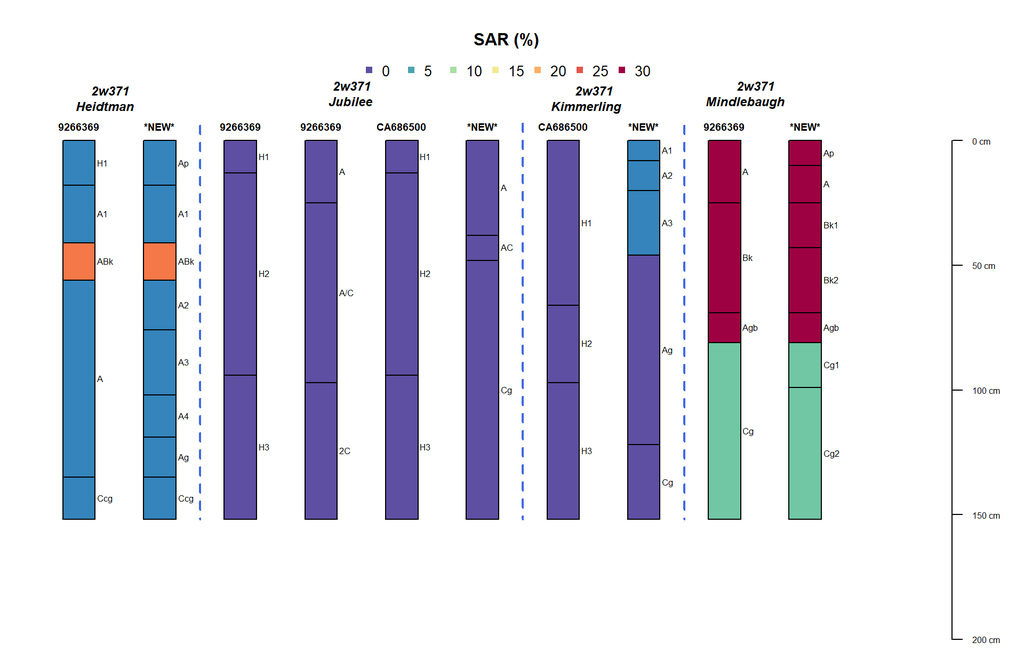

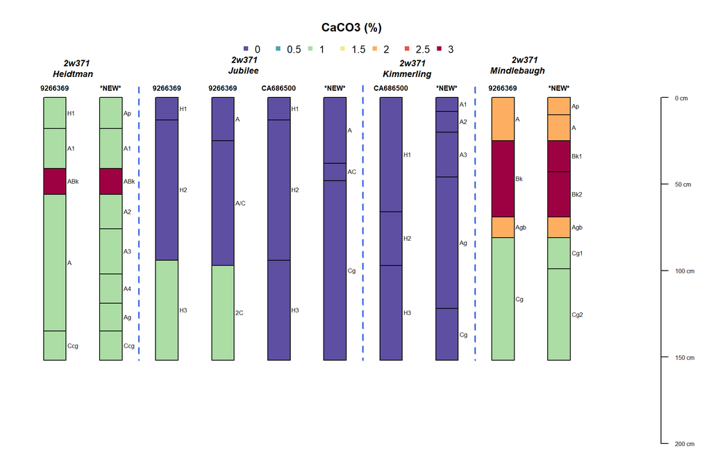

[4 more figures not shown]

## Component Month Summaries

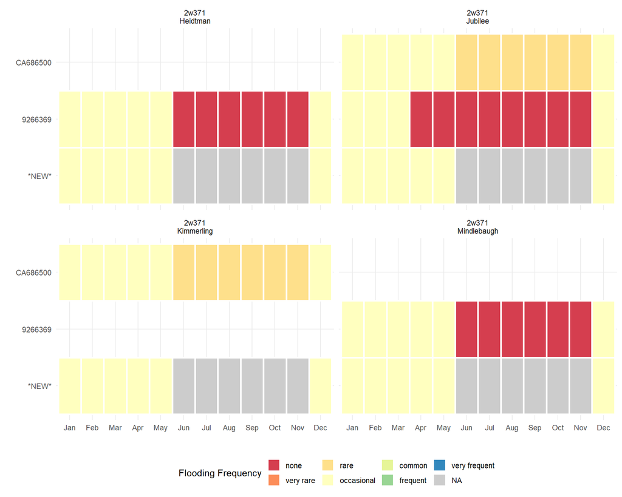

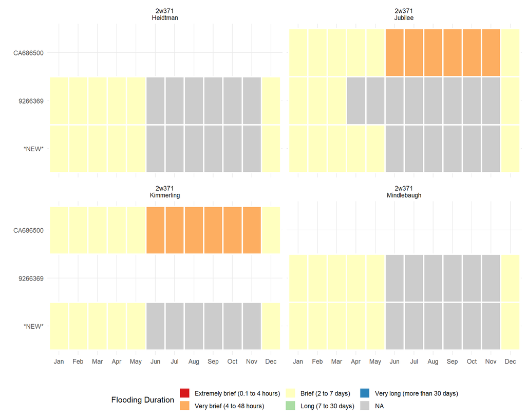

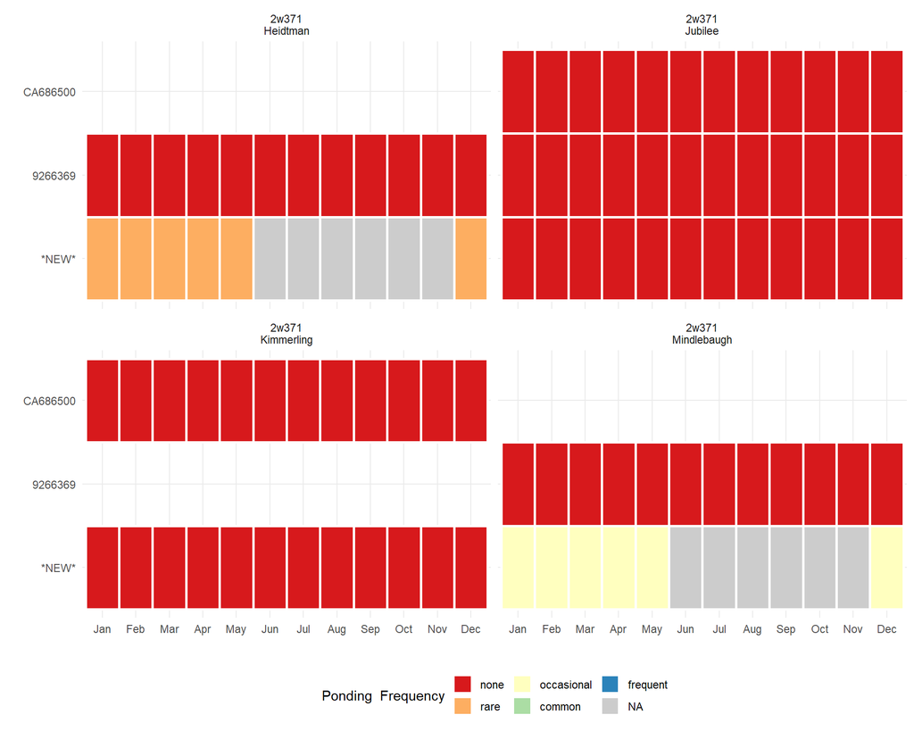

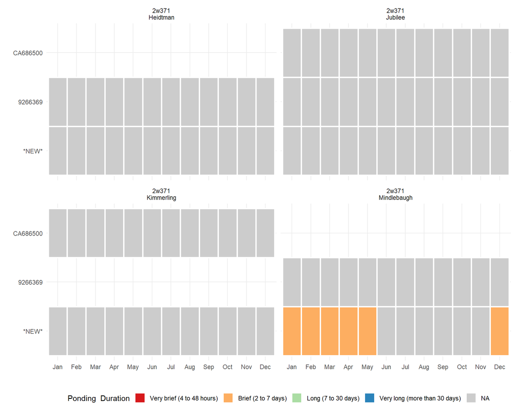

## RV Summaries by Depth

Median component RV along 1cm slices, grouped by component name and mapunit type ("new" vs. "old").

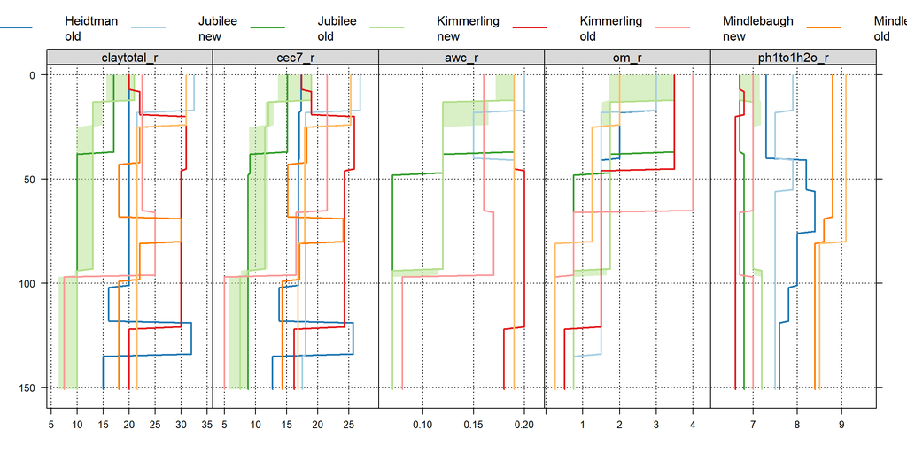

Median component RV along 1cm slices, grouped by component name and mapunit type ("new" vs. "old"), and split into panels by national map unit symbol.

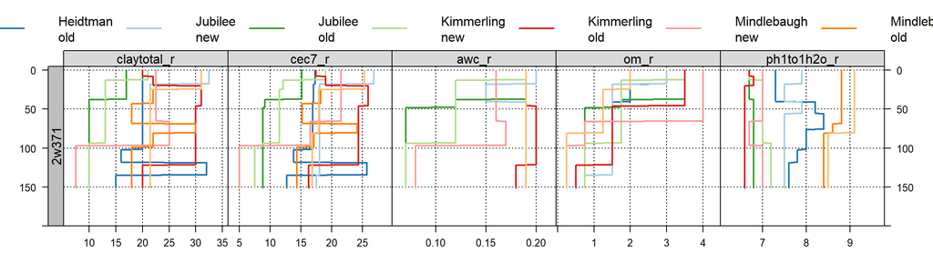

This document is based on `soilDB` version 2.2-2 and `aqp` version 1.16-2.  
Report [configuration and source code are hosted on GitHub](https://github.com/ncss-tech/soilReports).